# Risk Factor Analysis

## Outcome Variable

**Outcome Variable:** stunted

## Predictor Variables

**Intervention Variable:** tr

**Adjustment Set:**

unadjusted

## Stratifying Variables

The analysis was stratified on these variable(s):

- agecat
- studyid
- country
- intXenstunt

## Data Summary

| agecat | studyid | country | intXenstunt | stunted | n_cell | n |
| --- | --- | --- | --- | --- | --- | --- |
| Birth | iLiNS_DYADM_LNS | MALAWI | 1_Birth | 0 | 0 | 1 |
| Birth | iLiNS_DYADM_LNS | MALAWI | 1_Birth | 1 | 1 | 1 |
| Birth | ki1000125-AgaKhanUniv | PAKISTAN | 0_Birth | 0 | 11 | 11 |
| Birth | ki1000125-AgaKhanUniv | PAKISTAN | 0_Birth | 1 | 0 | 11 |
| Birth | ki1000304b-SAS-CompFeed | INDIA | 0_Birth | 0 | 106 | 106 |
| Birth | ki1000304b-SAS-CompFeed | INDIA | 0_Birth | 1 | 0 | 106 |
| Birth | ki1000304b-SAS-CompFeed | INDIA | 1_Birth | 0 | 0 | 38 |
| Birth | ki1000304b-SAS-CompFeed | INDIA | 1_Birth | 1 | 38 | 38 |
| Birth | ki1119695-PROBIT | BELARUS | 0_Birth | 0 | 13851 | 13851 |
| Birth | ki1119695-PROBIT | BELARUS | 0_Birth | 1 | 0 | 13851 |
| Birth | ki1119695-PROBIT | BELARUS | 1_Birth | 0 | 0 | 33 |
| Birth | ki1119695-PROBIT | BELARUS | 1_Birth | 1 | 33 | 33 |
| Birth | ki1126311-ZVITAMBO | ZIMBABWE | 0_Birth | 0 | 12398 | 12398 |
| Birth | ki1126311-ZVITAMBO | ZIMBABWE | 0_Birth | 1 | 0 | 12398 |
| Birth | ki1126311-ZVITAMBO | ZIMBABWE | 1_Birth | 0 | 0 | 1432 |
| Birth | ki1126311-ZVITAMBO | ZIMBABWE | 1_Birth | 1 | 1432 | 1432 |
| Birth | ki1135781-COHORTS | GUATEMALA | 0_Birth | 0 | 802 | 802 |
| Birth | ki1135781-COHORTS | GUATEMALA | 0_Birth | 1 | 0 | 802 |
| Birth | ki1135781-COHORTS | GUATEMALA | 1_Birth | 0 | 0 | 50 |
| Birth | ki1135781-COHORTS | GUATEMALA | 1_Birth | 1 | 50 | 50 |
| Birth | ki1148112-iLiNS-DYAD-M | MALAWI | 1_Birth | 0 | 0 | 1 |
| Birth | ki1148112-iLiNS-DYAD-M | MALAWI | 1_Birth | 1 | 1 | 1 |
| Birth | kiGH5241-JiVitA-3 | BANGLADESH | 0_Birth | 0 | 26550 | 26550 |
| Birth | kiGH5241-JiVitA-3 | BANGLADESH | 0_Birth | 1 | 0 | 26550 |
| Birth | kiGH5241-JiVitA-3 | BANGLADESH | 1_Birth | 0 | 0 | 12676 |
| Birth | kiGH5241-JiVitA-3 | BANGLADESH | 1_Birth | 1 | 12676 | 12676 |
| Birth | kiGH5241-JiVitA-4 | BANGLADESH | 0_Birth | 0 | 1150 | 1150 |
| Birth | kiGH5241-JiVitA-4 | BANGLADESH | 0_Birth | 1 | 0 | 1150 |
| Birth | kiGH5241-JiVitA-4 | BANGLADESH | 1_Birth | 0 | 0 | 494 |
| Birth | kiGH5241-JiVitA-4 | BANGLADESH | 1_Birth | 1 | 494 | 494 |

[output cut: 164 more lines]

The following strata were considered:

- agecat: 24 months, studyid: iLiNS_DYADM_LNS, country: MALAWI, intXenstunt: 0_24 months
- agecat: 24 months, studyid: iLiNS_DYADM_LNS, country: MALAWI, intXenstunt: 1_24 months
- agecat: 24 months, studyid: ki1000107-Serrinha-VitA, country: BRAZIL, intXenstunt: 0_24 months
- agecat: 24 months, studyid: ki1000107-Serrinha-VitA, country: BRAZIL, intXenstunt: 1_24 months
- agecat: 24 months, studyid: ki1000110-WASH-Bangladesh, country: BANGLADESH, intXenstunt: 0_24 months
- agecat: 24 months, studyid: ki1000110-WASH-Bangladesh, country: BANGLADESH, intXenstunt: 1_24 months
- agecat: 24 months, studyid: ki1000111-WASH-Kenya, country: KENYA, intXenstunt: 0_24 months
- agecat: 24 months, studyid: ki1000111-WASH-Kenya, country: KENYA, intXenstunt: 1_24 months
- agecat: 24 months, studyid: ki1000125-AgaKhanUniv, country: PAKISTAN, intXenstunt: 0_24 months
- agecat: 24 months, studyid: ki1000125-AgaKhanUniv, country: PAKISTAN, intXenstunt: 1_24 months
- agecat: 24 months, studyid: ki1000304-EU, country: INDIA, intXenstunt: 0_24 months
- agecat: 24 months, studyid: ki1000304-EU, country: INDIA, intXenstunt: 1_24 months
- agecat: 24 months, studyid: ki1000304-Vitamin-B12, country: INDIA, intXenstunt: 0_24 months
- agecat: 24 months, studyid: ki1000304-Vitamin-B12, country: INDIA, intXenstunt: 1_24 months
- agecat: 24 months, studyid: ki1000304-ZnMort, country: INDIA, intXenstunt: 0_24 months
- agecat: 24 months, studyid: ki1000304-ZnMort, country: INDIA, intXenstunt: 1_24 months
- agecat: 24 months, studyid: ki1017093b-PROVIDE, country: BANGLADESH, intXenstunt: 0_24 months
- agecat: 24 months, studyid: ki1066203-TanzaniaChild2, country: TANZANIA, UNITED REPUBLIC OF, intXenstunt: 0_24 months
- agecat: 24 months, studyid: ki1112895-Burkina Faso Zn, country: BURKINA FASO, intXenstunt: 0_24 months
- agecat: 24 months, studyid: ki1112895-Burkina Faso Zn, country: BURKINA FASO, intXenstunt: 1_24 months
- agecat: 24 months, studyid: ki1119695-PROBIT, country: BELARUS, intXenstunt: 0_24 months
- agecat: 24 months, studyid: ki1119695-PROBIT, country: BELARUS, intXenstunt: 1_24 months
- agecat: 24 months, studyid: ki1126311-ZVITAMBO, country: ZIMBABWE, intXenstunt: 0_24 months
- agecat: 24 months, studyid: ki1126311-ZVITAMBO, country: ZIMBABWE, intXenstunt: 1_24 months
- agecat: 24 months, studyid: ki1135781-COHORTS, country: GUATEMALA, intXenstunt: 0_24 months
- agecat: 24 months, studyid: ki1135781-COHORTS, country: GUATEMALA, intXenstunt: 1_24 months
- agecat: 24 months, studyid: ki1148112-iLiNS-DOSE, country: MALAWI, intXenstunt: 0_24 months
- agecat: 24 months, studyid: ki1148112-iLiNS-DOSE, country: MALAWI, intXenstunt: 1_24 months
- agecat: 24 months, studyid: ki1148112-iLiNS-DYAD-M, country: MALAWI, intXenstunt: 0_24 months
- agecat: 24 months, studyid: ki1148112-iLiNS-DYAD-M, country: MALAWI, intXenstunt: 1_24 months
- agecat: 24 months, studyid: ki1148112-LCNI-5, country: MALAWI, intXenstunt: 0_24 months
- agecat: 24 months, studyid: ki1148112-LCNI-5, country: MALAWI, intXenstunt: 1_24 months
- agecat: 24 months, studyid: kiGH5241-JiVitA-3, country: BANGLADESH, intXenstunt: 0_24 months
- agecat: 24 months, studyid: kiGH5241-JiVitA-3, country: BANGLADESH, intXenstunt: 1_24 months
- agecat: 24 months, studyid: kiGH5241-JiVitA-4, country: BANGLADESH, intXenstunt: 0_24 months
- agecat: 24 months, studyid: kiGH5241-JiVitA-4, country: BANGLADESH, intXenstunt: 1_24 months
- agecat: 6 months, studyid: iLiNS_DYADM_LNS, country: MALAWI, intXenstunt: 0_6 months
- agecat: 6 months, studyid: iLiNS_DYADM_LNS, country: MALAWI, intXenstunt: 1_6 months
- agecat: 6 months, studyid: ki1000107-Serrinha-VitA, country: BRAZIL, intXenstunt: 0_6 months
- agecat: 6 months, studyid: ki1000107-Serrinha-VitA, country: BRAZIL, intXenstunt: 1_6 months
- agecat: 6 months, studyid: ki1000110-WASH-Bangladesh, country: BANGLADESH, intXenstunt: 0_6 months
- agecat: 6 months, studyid: ki1000110-WASH-Bangladesh, country: BANGLADESH, intXenstunt: 1_6 months
- agecat: 6 months, studyid: ki1000111-WASH-Kenya, country: KENYA, intXenstunt: 0_6 months
- agecat: 6 months, studyid: ki1000111-WASH-Kenya, country: KENYA, intXenstunt: 1_6 months
- agecat: 6 months, studyid: ki1000125-AgaKhanUniv, country: PAKISTAN, intXenstunt: 0_6 months
- agecat: 6 months, studyid: ki1000125-AgaKhanUniv, country: PAKISTAN, intXenstunt: 1_6 months
- agecat: 6 months, studyid: ki1000304-EU, country: INDIA, intXenstunt: 0_6 months
- agecat: 6 months, studyid: ki1000304-EU, country: INDIA, intXenstunt: 1_6 months
- agecat: 6 months, studyid: ki1000304-VITAMIN-A, country: INDIA, intXenstunt: 0_6 months
- agecat: 6 months, studyid: ki1000304-VITAMIN-A, country: INDIA, intXenstunt: 1_6 months
- agecat: 6 months, studyid: ki1000304-Vitamin-B12, country: INDIA, intXenstunt: 0_6 months
- agecat: 6 months, studyid: ki1000304-Vitamin-B12, country: INDIA, intXenstunt: 1_6 months
- agecat: 6 months, studyid: ki1000304-ZnMort, country: INDIA, intXenstunt: 0_6 months
- agecat: 6 months, studyid: ki1000304-ZnMort, country: INDIA, intXenstunt: 1_6 months
- agecat: 6 months, studyid: ki1000304b-SAS-CompFeed, country: INDIA, intXenstunt: 0_6 months
- agecat: 6 months, studyid: ki1000304b-SAS-CompFeed, country: INDIA, intXenstunt: 1_6 months
- agecat: 6 months, studyid: ki1000304b-SAS-FoodSuppl, country: INDIA, intXenstunt: 0_6 months
- agecat: 6 months, studyid: ki1000304b-SAS-FoodSuppl, country: INDIA, intXenstunt: 1_6 months
- agecat: 6 months, studyid: ki1017093b-PROVIDE, country: BANGLADESH, intXenstunt: 0_6 months
- agecat: 6 months, studyid: ki1017093b-PROVIDE, country: BANGLADESH, intXenstunt: 1_6 months
- agecat: 6 months, studyid: ki1066203-TanzaniaChild2, country: TANZANIA, UNITED REPUBLIC OF, intXenstunt: 0_6 months
- agecat: 6 months, studyid: ki1066203-TanzaniaChild2, country: TANZANIA, UNITED REPUBLIC OF, intXenstunt: 1_6 months
- agecat: 6 months, studyid: ki1112895-Burkina Faso Zn, country: BURKINA FASO, intXenstunt: 0_6 months
- agecat: 6 months, studyid: ki1112895-Burkina Faso Zn, country: BURKINA FASO, intXenstunt: 1_6 months
- agecat: 6 months, studyid: ki1112895-Guatemala BSC, country: GUATEMALA, intXenstunt: 0_6 months
- agecat: 6 months, studyid: ki1112895-Guatemala BSC, country: GUATEMALA, intXenstunt: 1_6 months
- agecat: 6 months, studyid: ki1119695-PROBIT, country: BELARUS, intXenstunt: 0_6 months
- agecat: 6 months, studyid: ki1119695-PROBIT, country: BELARUS, intXenstunt: 1_6 months
- agecat: 6 months, studyid: ki1126311-ZVITAMBO, country: ZIMBABWE, intXenstunt: 0_6 months
- agecat: 6 months, studyid: ki1126311-ZVITAMBO, country: ZIMBABWE, intXenstunt: 1_6 months
- agecat: 6 months, studyid: ki1135781-COHORTS, country: GUATEMALA, intXenstunt: 0_6 months
- agecat: 6 months, studyid: ki1135781-COHORTS, country: GUATEMALA, intXenstunt: 1_6 months
- agecat: 6 months, studyid: ki1148112-iLiNS-DOSE, country: MALAWI, intXenstunt: 0_6 months
- agecat: 6 months, studyid: ki1148112-iLiNS-DOSE, country: MALAWI, intXenstunt: 1_6 months
- agecat: 6 months, studyid: ki1148112-iLiNS-DYAD-M, country: MALAWI, intXenstunt: 0_6 months
- agecat: 6 months, studyid: ki1148112-iLiNS-DYAD-M, country: MALAWI, intXenstunt: 1_6 months
- agecat: 6 months, studyid: ki1148112-LCNI-5, country: MALAWI, intXenstunt: 0_6 months
- agecat: 6 months, studyid: ki1148112-LCNI-5, country: MALAWI, intXenstunt: 1_6 months
- agecat: 6 months, studyid: kiGH5241-JiVitA-3, country: BANGLADESH, intXenstunt: 0_6 months
- agecat: 6 months, studyid: kiGH5241-JiVitA-3, country: BANGLADESH, intXenstunt: 1_6 months
- agecat: 6 months, studyid: kiGH5241-JiVitA-4, country: BANGLADESH, intXenstunt: 0_6 months
- agecat: 6 months, studyid: kiGH5241-JiVitA-4, country: BANGLADESH, intXenstunt: 1_6 months
- agecat: Birth, studyid: iLiNS_DYADM_LNS, country: MALAWI, intXenstunt: 1_Birth
- agecat: Birth, studyid: ki1000125-AgaKhanUniv, country: PAKISTAN, intXenstunt: 0_Birth
- agecat: Birth, studyid: ki1000304b-SAS-CompFeed, country: INDIA, intXenstunt: 0_Birth
- agecat: Birth, studyid: ki1000304b-SAS-CompFeed, country: INDIA, intXenstunt: 1_Birth
- agecat: Birth, studyid: ki1119695-PROBIT, country: BELARUS, intXenstunt: 0_Birth
- agecat: Birth, studyid: ki1119695-PROBIT, country: BELARUS, intXenstunt: 1_Birth
- agecat: Birth, studyid: ki1126311-ZVITAMBO, country: ZIMBABWE, intXenstunt: 0_Birth
- agecat: Birth, studyid: ki1126311-ZVITAMBO, country: ZIMBABWE, intXenstunt: 1_Birth
- agecat: Birth, studyid: ki1135781-COHORTS, country: GUATEMALA, intXenstunt: 0_Birth
- agecat: Birth, studyid: ki1135781-COHORTS, country: GUATEMALA, intXenstunt: 1_Birth
- agecat: Birth, studyid: ki1148112-iLiNS-DYAD-M, country: MALAWI, intXenstunt: 1_Birth
- agecat: Birth, studyid: kiGH5241-JiVitA-3, country: BANGLADESH, intXenstunt: 0_Birth
- agecat: Birth, studyid: kiGH5241-JiVitA-3, country: BANGLADESH, intXenstunt: 1_Birth
- agecat: Birth, studyid: kiGH5241-JiVitA-4, country: BANGLADESH, intXenstunt: 0_Birth
- agecat: Birth, studyid: kiGH5241-JiVitA-4, country: BANGLADESH, intXenstunt: 1_Birth

### Dropped Strata

Some strata were dropped due to rare outcomes:

- agecat: Birth, studyid: iLiNS_DYADM_LNS, country: MALAWI, intXenstunt: 1_Birth
- agecat: Birth, studyid: ki1000125-AgaKhanUniv, country: PAKISTAN, intXenstunt: 0_Birth
- agecat: Birth, studyid: ki1000304b-SAS-CompFeed, country: INDIA, intXenstunt: 0_Birth
- agecat: Birth, studyid: ki1000304b-SAS-CompFeed, country: INDIA, intXenstunt: 1_Birth
- agecat: Birth, studyid: ki1119695-PROBIT, country: BELARUS, intXenstunt: 0_Birth
- agecat: Birth, studyid: ki1119695-PROBIT, country: BELARUS, intXenstunt: 1_Birth
- agecat: Birth, studyid: ki1126311-ZVITAMBO, country: ZIMBABWE, intXenstunt: 0_Birth
- agecat: Birth, studyid: ki1126311-ZVITAMBO, country: ZIMBABWE, intXenstunt: 1_Birth
- agecat: Birth, studyid: ki1135781-COHORTS, country: GUATEMALA, intXenstunt: 0_Birth
- agecat: Birth, studyid: ki1135781-COHORTS, country: GUATEMALA, intXenstunt: 1_Birth
- agecat: Birth, studyid: ki1148112-iLiNS-DYAD-M, country: MALAWI, intXenstunt: 1_Birth
- agecat: Birth, studyid: kiGH5241-JiVitA-3, country: BANGLADESH, intXenstunt: 0_Birth
- agecat: Birth, studyid: kiGH5241-JiVitA-3, country: BANGLADESH, intXenstunt: 1_Birth
- agecat: Birth, studyid: kiGH5241-JiVitA-4, country: BANGLADESH, intXenstunt: 0_Birth
- agecat: Birth, studyid: kiGH5241-JiVitA-4, country: BANGLADESH, intXenstunt: 1_Birth
- agecat: 6 months, studyid: ki1000107-Serrinha-VitA, country: BRAZIL, intXenstunt: 0_6 months
- agecat: 6 months, studyid: ki1000107-Serrinha-VitA, country: BRAZIL, intXenstunt: 1_6 months
- agecat: 6 months, studyid: ki1000110-WASH-Bangladesh, country: BANGLADESH, intXenstunt: 0_6 months
- agecat: 6 months, studyid: ki1000110-WASH-Bangladesh, country: BANGLADESH, intXenstunt: 1_6 months
- agecat: 6 months, studyid: ki1000111-WASH-Kenya, country: KENYA, intXenstunt: 0_6 months
- agecat: 6 months, studyid: ki1000111-WASH-Kenya, country: KENYA, intXenstunt: 1_6 months
- agecat: 6 months, studyid: ki1000304-EU, country: INDIA, intXenstunt: 0_6 months
- agecat: 6 months, studyid: ki1000304-EU, country: INDIA, intXenstunt: 1_6 months
- agecat: 6 months, studyid: ki1000304-Vitamin-B12, country: INDIA, intXenstunt: 0_6 months
- agecat: 6 months, studyid: ki1000304-Vitamin-B12, country: INDIA, intXenstunt: 1_6 months
- agecat: 6 months, studyid: ki1000304-ZnMort, country: INDIA, intXenstunt: 0_6 months
- agecat: 6 months, studyid: ki1000304-ZnMort, country: INDIA, intXenstunt: 1_6 months
- agecat: 6 months, studyid: ki1017093b-PROVIDE, country: BANGLADESH, intXenstunt: 1_6 months
- agecat: 6 months, studyid: ki1112895-Burkina Faso Zn, country: BURKINA FASO, intXenstunt: 0_6 months
- agecat: 6 months, studyid: ki1112895-Burkina Faso Zn, country: BURKINA FASO, intXenstunt: 1_6 months
- agecat: 6 months, studyid: ki1112895-Guatemala BSC, country: GUATEMALA, intXenstunt: 1_6 months
- agecat: 6 months, studyid: ki1148112-iLiNS-DOSE, country: MALAWI, intXenstunt: 0_6 months
- agecat: 6 months, studyid: ki1148112-iLiNS-DOSE, country: MALAWI, intXenstunt: 1_6 months
- agecat: 6 months, studyid: ki1148112-LCNI-5, country: MALAWI, intXenstunt: 0_6 months
- agecat: 6 months, studyid: ki1148112-LCNI-5, country: MALAWI, intXenstunt: 1_6 months
- agecat: 24 months, studyid: iLiNS_DYADM_LNS, country: MALAWI, intXenstunt: 1_24 months
- agecat: 24 months, studyid: ki1000107-Serrinha-VitA, country: BRAZIL, intXenstunt: 1_24 months
- agecat: 24 months, studyid: ki1000125-AgaKhanUniv, country: PAKISTAN, intXenstunt: 0_24 months
- agecat: 24 months, studyid: ki1000125-AgaKhanUniv, country: PAKISTAN, intXenstunt: 1_24 months
- agecat: 24 months, studyid: ki1000304-EU, country: INDIA, intXenstunt: 1_24 months
- agecat: 24 months, studyid: ki1000304-Vitamin-B12, country: INDIA, intXenstunt: 0_24 months
- agecat: 24 months, studyid: ki1000304-ZnMort, country: INDIA, intXenstunt: 0_24 months
- agecat: 24 months, studyid: ki1000304-ZnMort, country: INDIA, intXenstunt: 1_24 months
- agecat: 24 months, studyid: ki1017093b-PROVIDE, country: BANGLADESH, intXenstunt: 0_24 months
- agecat: 24 months, studyid: ki1066203-TanzaniaChild2, country: TANZANIA, UNITED REPUBLIC OF, intXenstunt: 0_24 months
- agecat: 24 months, studyid: ki1119695-PROBIT, country: BELARUS, intXenstunt: 1_24 months
- agecat: 24 months, studyid: ki1126311-ZVITAMBO, country: ZIMBABWE, intXenstunt: 1_24 months

## Methods Detail

We’re interested in the causal parameters $E[Y_a]$ for all values of $a \in \mathcal{A}$. These parameters represent the mean outcome if, possibly contrary to fact, we intervened to set all units to have $A=a$. Under the randomization and positivity assumptions, these are identified by the statistical parameters $\psi_a=E_W[E_{Y|A,W}(Y|A=a,W)]$. In addition, we’re interested in the mean of $Y$, $E[Y]$ under no intervention (the observed mean). We will estimate these parameters by using SuperLearner to fit the relevant likelihood factors – $E_{Y|A,W}(Y|A=a,W)$ and $p(A=a|W)$, and then updating our likelihood fit using a joint TMLE.

For unadjusted analyses ($W=\{\}$), initial likelihoods were estimated using Lrnr_glm to estimate the simple $E(Y|A)$ and Lrnr_mean to estimate $p(A)$. For adjusted analyses, a small library containing Lrnr_glmnet, Lrnr_xgboost, and Lrnr_mean was used.

Having estimated these parameters, we will then use the delta method to estimate relative risks and attributable risks relative to a prespecified baseline level of $A$.

# Results Detail

## Results Plots

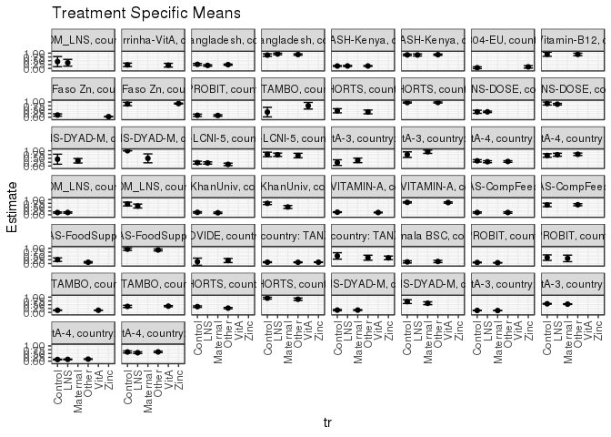

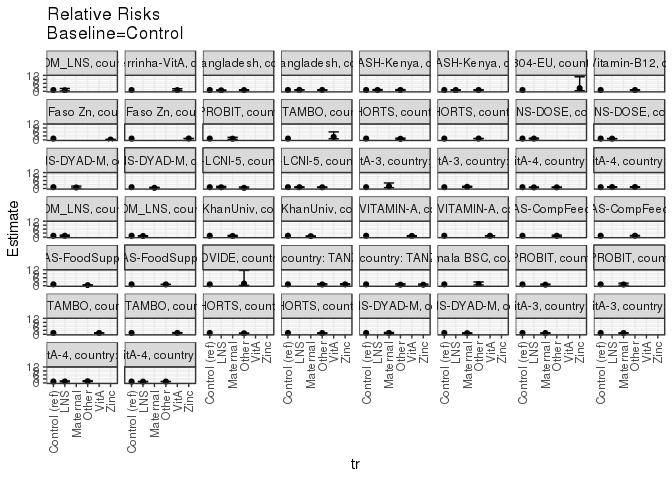

[figure not shown]

[figure not shown]

## Results Table

### Parameter: TSM

| agecat | studyid | country | intXenstunt | intervention_level | baseline_level | estimate | ci_lower | ci_upper |
| --- | --- | --- | --- | --- | --- | --- | --- | --- |
| 6 months | iLiNS_DYADM_LNS | MALAWI | 0_6 months | Control | NA | 0.1481481 | 0.1077111 | 0.1885852 |
| 6 months | iLiNS_DYADM_LNS | MALAWI | 0_6 months | LNS | NA | 0.1485507 | 0.1065565 | 0.1905450 |
| 6 months | iLiNS_DYADM_LNS | MALAWI | 1_6 months | Control | NA | 0.7037037 | 0.5813570 | 0.8260504 |
| 6 months | iLiNS_DYADM_LNS | MALAWI | 1_6 months | LNS | NA | 0.5714286 | 0.4412229 | 0.7016342 |
| 6 months | ki1000125-AgaKhanUniv | PAKISTAN | 0_6 months | Control | NA | 0.1573034 | 0.1135872 | 0.2010195 |
| 6 months | ki1000125-AgaKhanUniv | PAKISTAN | 0_6 months | Maternal | NA | 0.1306306 | 0.0862554 | 0.1750059 |
| 6 months | ki1000125-AgaKhanUniv | PAKISTAN | 1_6 months | Control | NA | 0.7500000 | 0.6681359 | 0.8318641 |
| 6 months | ki1000125-AgaKhanUniv | PAKISTAN | 1_6 months | Maternal | NA | 0.5102041 | 0.4109905 | 0.6094177 |
| 6 months | ki1000304-VITAMIN-A | INDIA | 0_6 months | Control | NA | 0.1687151 | 0.1441731 | 0.1932571 |
| 6 months | ki1000304-VITAMIN-A | INDIA | 0_6 months | VitA | NA | 0.1486034 | 0.1252936 | 0.1719131 |
| 6 months | ki1000304-VITAMIN-A | INDIA | 1_6 months | Control | NA | 0.8135135 | 0.7737984 | 0.8532286 |
| 6 months | ki1000304-VITAMIN-A | INDIA | 1_6 months | VitA | NA | 0.8017241 | 0.7598054 | 0.8436429 |
| 6 months | ki1000304b-SAS-CompFeed | INDIA | 0_6 months | Control | NA | 0.1506849 | 0.1086413 | 0.1927286 |
| 6 months | ki1000304b-SAS-CompFeed | INDIA | 0_6 months | Other | NA | 0.1476793 | 0.0995980 | 0.1957606 |
| 6 months | ki1000304b-SAS-CompFeed | INDIA | 1_6 months | Control | NA | 0.6447368 | 0.5299648 | 0.7595089 |
| 6 months | ki1000304b-SAS-CompFeed | INDIA | 1_6 months | Other | NA | 0.6588235 | 0.5921872 | 0.7254598 |
| 6 months | ki1000304b-SAS-FoodSuppl | INDIA | 0_6 months | Control | NA | 0.2545455 | 0.1391593 | 0.3699316 |
| 6 months | ki1000304b-SAS-FoodSuppl | INDIA | 0_6 months | Other | NA | 0.0853659 | 0.0425025 | 0.1282292 |
| 6 months | ki1000304b-SAS-FoodSuppl | INDIA | 1_6 months | Control | NA | 0.9428571 | 0.8656743 | 1.0200399 |
| 6 months | ki1000304b-SAS-FoodSuppl | INDIA | 1_6 months | Other | NA | 0.8910891 | 0.8301093 | 0.9520689 |
| 6 months | ki1017093b-PROVIDE | BANGLADESH | 0_6 months | Control | NA | 0.1250000 | -0.1068845 | 0.3568845 |
| 6 months | ki1017093b-PROVIDE | BANGLADESH | 0_6 months | Other | NA | 0.2000000 | 0.0659139 | 0.3340861 |
| 6 months | ki1066203-TanzaniaChild2 | TANZANIA, UNITED REPUBLIC OF | 0_6 months | Control | NA | 0.0893300 | 0.0614745 | 0.1171856 |
| 6 months | ki1066203-TanzaniaChild2 | TANZANIA, UNITED REPUBLIC OF | 0_6 months | Other | NA | 0.0820513 | 0.0548052 | 0.1092974 |
| 6 months | ki1066203-TanzaniaChild2 | TANZANIA, UNITED REPUBLIC OF | 0_6 months | Zinc | NA | 0.0891960 | 0.0693892 | 0.1090027 |
| 6 months | ki1066203-TanzaniaChild2 | TANZANIA, UNITED REPUBLIC OF | 1_6 months | Control | NA | 0.5000000 | 0.2901762 | 0.7098238 |
| 6 months | ki1066203-TanzaniaChild2 | TANZANIA, UNITED REPUBLIC OF | 1_6 months | Other | NA | 0.3823529 | 0.2183094 | 0.5463965 |
| 6 months | ki1066203-TanzaniaChild2 | TANZANIA, UNITED REPUBLIC OF | 1_6 months | Zinc | NA | 0.3709677 | 0.2502128 | 0.4917227 |
| 6 months | ki1112895-Guatemala BSC | GUATEMALA | 0_6 months | Control | NA | 0.1097561 | 0.0418997 | 0.1776125 |
| 6 months | ki1112895-Guatemala BSC | GUATEMALA | 0_6 months | Other | NA | 0.1363636 | 0.0644514 | 0.2082758 |

[output cut: 82 more lines]

### Parameter: E(Y)

| agecat | studyid | country | intXenstunt | intervention_level | baseline_level | estimate | ci_lower | ci_upper |
| --- | --- | --- | --- | --- | --- | --- | --- | --- |
| 6 months | iLiNS_DYADM_LNS | MALAWI | 0_6 months | NA | NA | 0.1483421 | 0.1192138 | 0.1774703 |
| 6 months | iLiNS_DYADM_LNS | MALAWI | 1_6 months | NA | NA | 0.6363636 | 0.5460567 | 0.7266706 |
| 6 months | ki1000125-AgaKhanUniv | PAKISTAN | 0_6 months | NA | NA | 0.1451943 | 0.1139373 | 0.1764512 |
| 6 months | ki1000125-AgaKhanUniv | PAKISTAN | 1_6 months | NA | NA | 0.6359223 | 0.5700550 | 0.7017897 |
| 6 months | ki1000304-VITAMIN-A | INDIA | 0_6 months | NA | NA | 0.1586592 | 0.1417290 | 0.1755894 |
| 6 months | ki1000304-VITAMIN-A | INDIA | 1_6 months | NA | NA | 0.8077994 | 0.7789580 | 0.8366409 |
| 6 months | ki1000304b-SAS-CompFeed | INDIA | 0_6 months | NA | NA | 0.1491228 | 0.1168079 | 0.1814377 |
| 6 months | ki1000304b-SAS-CompFeed | INDIA | 1_6 months | NA | NA | 0.6521739 | 0.5876398 | 0.7167080 |
| 6 months | ki1000304b-SAS-FoodSuppl | INDIA | 0_6 months | NA | NA | 0.1278539 | 0.0835266 | 0.1721812 |
| 6 months | ki1000304b-SAS-FoodSuppl | INDIA | 1_6 months | NA | NA | 0.9044118 | 0.8548135 | 0.9540100 |
| 6 months | ki1017093b-PROVIDE | BANGLADESH | 0_6 months | NA | NA | 0.1860465 | 0.0683580 | 0.3037350 |
| 6 months | ki1066203-TanzaniaChild2 | TANZANIA, UNITED REPUBLIC OF | 0_6 months | NA | NA | 0.0874764 | 0.0735804 | 0.1013724 |
| 6 months | ki1066203-TanzaniaChild2 | TANZANIA, UNITED REPUBLIC OF | 1_6 months | NA | NA | 0.3983051 | 0.3095994 | 0.4870107 |
| 6 months | ki1112895-Guatemala BSC | GUATEMALA | 0_6 months | NA | NA | 0.1235294 | 0.0739206 | 0.1731382 |
| 6 months | ki1119695-PROBIT | BELARUS | 0_6 months | NA | NA | 0.0613181 | 0.0465049 | 0.0761314 |
| 6 months | ki1119695-PROBIT | BELARUS | 1_6 months | NA | NA | 0.3620690 | 0.2206531 | 0.5034848 |
| 6 months | ki1126311-ZVITAMBO | ZIMBABWE | 0_6 months | NA | NA | 0.1385542 | 0.1304442 | 0.1466643 |
| 6 months | ki1126311-ZVITAMBO | ZIMBABWE | 1_6 months | NA | NA | 0.4029851 | 0.3690595 | 0.4369107 |
| 6 months | ki1135781-COHORTS | GUATEMALA | 0_6 months | NA | NA | 0.3260870 | 0.2932100 | 0.3589639 |
| 6 months | ki1135781-COHORTS | GUATEMALA | 1_6 months | NA | NA | 0.8933333 | 0.8437682 | 0.9428984 |
| 6 months | ki1148112-iLiNS-DYAD-M | MALAWI | 0_6 months | NA | NA | 0.1483198 | 0.1245934 | 0.1720462 |
| 6 months | ki1148112-iLiNS-DYAD-M | MALAWI | 1_6 months | NA | NA | 0.6325301 | 0.5589674 | 0.7060928 |
| 6 months | kiGH5241-JiVitA-3 | BANGLADESH | 0_6 months | NA | NA | 0.1221961 | 0.1151937 | 0.1291986 |
| 6 months | kiGH5241-JiVitA-3 | BANGLADESH | 1_6 months | NA | NA | 0.5514983 | 0.5350358 | 0.5679608 |
| 6 months | kiGH5241-JiVitA-4 | BANGLADESH | 0_6 months | NA | NA | 0.1214190 | 0.1075405 | 0.1352975 |
| 6 months | kiGH5241-JiVitA-4 | BANGLADESH | 1_6 months | NA | NA | 0.5900340 | 0.5582752 | 0.6217927 |
| 24 months | iLiNS_DYADM_LNS | MALAWI | 0_24 months | NA | NA | 0.3928571 | 0.2086405 | 0.5770738 |
| 24 months | ki1000107-Serrinha-VitA | BRAZIL | 0_24 months | NA | NA | 0.2210526 | 0.1371673 | 0.3049380 |
| 24 months | ki1000110-WASH-Bangladesh | BANGLADESH | 0_24 months | NA | NA | 0.2358916 | 0.2079205 | 0.2638628 |
| 24 months | ki1000110-WASH-Bangladesh | BANGLADESH | 1_24 months | NA | NA | 0.9102990 | 0.8779636 | 0.9426344 |
| 24 months | ki1000111-WASH-Kenya | KENYA | 0_24 months | NA | NA | 0.1584213 | 0.1415439 | 0.1752988 |
| 24 months | ki1000111-WASH-Kenya | KENYA | 1_24 months | NA | NA | 0.8903226 | 0.8618897 | 0.9187555 |
| 24 months | ki1000304-EU | INDIA | 0_24 months | NA | NA | 0.0754717 | 0.0249468 | 0.1259966 |
| 24 months | ki1000304-Vitamin-B12 | INDIA | 1_24 months | NA | NA | 0.9193548 | 0.8510244 | 0.9876852 |
| 24 months | ki1112895-Burkina Faso Zn | BURKINA FASO | 0_24 months | NA | NA | 0.0472973 | 0.0319927 | 0.0626019 |
| 24 months | ki1112895-Burkina Faso Zn | BURKINA FASO | 1_24 months | NA | NA | 0.8904429 | 0.8608526 | 0.9200332 |
| 24 months | ki1119695-PROBIT | BELARUS | 0_24 months | NA | NA | 0.1168057 | 0.0733203 | 0.1602912 |
| 24 months | ki1126311-ZVITAMBO | ZIMBABWE | 0_24 months | NA | NA | 0.6000000 | 0.4040036 | 0.7959964 |
| 24 months | ki1135781-COHORTS | GUATEMALA | 0_24 months | NA | NA | 0.3809524 | 0.2876208 | 0.4742840 |
| 24 months | ki1135781-COHORTS | GUATEMALA | 1_24 months | NA | NA | 0.9608696 | 0.9357553 | 0.9859838 |
| 24 months | ki1148112-iLiNS-DOSE | MALAWI | 0_24 months | NA | NA | 0.3505535 | 0.3103468 | 0.3907602 |
| 24 months | ki1148112-iLiNS-DOSE | MALAWI | 1_24 months | NA | NA | 0.8589744 | 0.8142845 | 0.9036642 |
| 24 months | ki1148112-iLiNS-DYAD-M | MALAWI | 0_24 months | NA | NA | 0.3600000 | 0.2256025 | 0.4943975 |
| 24 months | ki1148112-iLiNS-DYAD-M | MALAWI | 1_24 months | NA | NA | 0.6000000 | 0.3433805 | 0.8566195 |
| 24 months | ki1148112-LCNI-5 | MALAWI | 0_24 months | NA | NA | 0.1840000 | 0.1358715 | 0.2321285 |
| 24 months | ki1148112-LCNI-5 | MALAWI | 1_24 months | NA | NA | 0.7259259 | 0.6504035 | 0.8014483 |
| 24 months | kiGH5241-JiVitA-3 | BANGLADESH | 0_24 months | NA | NA | 0.3118280 | 0.1933892 | 0.4302667 |
| 24 months | kiGH5241-JiVitA-3 | BANGLADESH | 1_24 months | NA | NA | 0.8307692 | 0.7160532 | 0.9454853 |
| 24 months | kiGH5241-JiVitA-4 | BANGLADESH | 0_24 months | NA | NA | 0.3007468 | 0.2645611 | 0.3369324 |
| 24 months | kiGH5241-JiVitA-4 | BANGLADESH | 1_24 months | NA | NA | 0.7363465 | 0.6808359 | 0.7918571 |

### Parameter: RR

| agecat | studyid | country | intXenstunt | intervention_level | baseline_level | estimate | ci_lower | ci_upper |
| --- | --- | --- | --- | --- | --- | --- | --- | --- |
| 6 months | iLiNS_DYADM_LNS | MALAWI | 0_6 months | Control | Control | 1.0000000 | 1.0000000 | 1.0000000 |
| 6 months | iLiNS_DYADM_LNS | MALAWI | 0_6 months | LNS | Control | 1.0027174 | 0.6768907 | 1.4853834 |
| 6 months | iLiNS_DYADM_LNS | MALAWI | 1_6 months | Control | Control | 1.0000000 | 1.0000000 | 1.0000000 |
| 6 months | iLiNS_DYADM_LNS | MALAWI | 1_6 months | LNS | Control | 0.8120301 | 0.6096732 | 1.0815514 |
| 6 months | ki1000125-AgaKhanUniv | PAKISTAN | 0_6 months | Control | Control | 1.0000000 | 1.0000000 | 1.0000000 |
| 6 months | ki1000125-AgaKhanUniv | PAKISTAN | 0_6 months | Maternal | Control | 0.8304376 | 0.5354227 | 1.2880041 |
| 6 months | ki1000125-AgaKhanUniv | PAKISTAN | 1_6 months | Control | Control | 1.0000000 | 1.0000000 | 1.0000000 |
| 6 months | ki1000125-AgaKhanUniv | PAKISTAN | 1_6 months | Maternal | Control | 0.6802721 | 0.5442966 | 0.8502169 |
| 6 months | ki1000304-VITAMIN-A | INDIA | 0_6 months | Control | Control | 1.0000000 | 1.0000000 | 1.0000000 |
| 6 months | ki1000304-VITAMIN-A | INDIA | 0_6 months | VitA | Control | 0.8807947 | 0.7111604 | 1.0908922 |
| 6 months | ki1000304-VITAMIN-A | INDIA | 1_6 months | Control | Control | 1.0000000 | 1.0000000 | 1.0000000 |
| 6 months | ki1000304-VITAMIN-A | INDIA | 1_6 months | VitA | Control | 0.9855081 | 0.9174731 | 1.0585882 |
| 6 months | ki1000304b-SAS-CompFeed | INDIA | 0_6 months | Control | Control | 1.0000000 | 1.0000000 | 1.0000000 |
| 6 months | ki1000304b-SAS-CompFeed | INDIA | 0_6 months | Other | Control | 0.9800537 | 0.6388668 | 1.5034516 |
| 6 months | ki1000304b-SAS-CompFeed | INDIA | 1_6 months | Control | Control | 1.0000000 | 1.0000000 | 1.0000000 |
| 6 months | ki1000304b-SAS-CompFeed | INDIA | 1_6 months | Other | Control | 1.0218487 | 0.8308455 | 1.2567618 |
| 6 months | ki1000304b-SAS-FoodSuppl | INDIA | 0_6 months | Control | Control | 1.0000000 | 1.0000000 | 1.0000000 |
| 6 months | ki1000304b-SAS-FoodSuppl | INDIA | 0_6 months | Other | Control | 0.3353659 | 0.1705042 | 0.6596334 |
| 6 months | ki1000304b-SAS-FoodSuppl | INDIA | 1_6 months | Control | Control | 1.0000000 | 1.0000000 | 1.0000000 |
| 6 months | ki1000304b-SAS-FoodSuppl | INDIA | 1_6 months | Other | Control | 0.9450945 | 0.8494492 | 1.0515092 |
| 6 months | ki1017093b-PROVIDE | BANGLADESH | 0_6 months | Control | Control | 1.0000000 | 1.0000000 | 1.0000000 |
| 6 months | ki1017093b-PROVIDE | BANGLADESH | 0_6 months | Other | Control | 1.6000000 | 0.2225723 | 11.5018809 |
| 6 months | ki1066203-TanzaniaChild2 | TANZANIA, UNITED REPUBLIC OF | 0_6 months | Control | Control | 1.0000000 | 1.0000000 | 1.0000000 |
| 6 months | ki1066203-TanzaniaChild2 | TANZANIA, UNITED REPUBLIC OF | 0_6 months | Other | Control | 0.9185185 | 0.5824474 | 1.4485020 |
| 6 months | ki1066203-TanzaniaChild2 | TANZANIA, UNITED REPUBLIC OF | 0_6 months | Zinc | Control | 0.9984994 | 0.6809166 | 1.4642044 |
| 6 months | ki1066203-TanzaniaChild2 | TANZANIA, UNITED REPUBLIC OF | 1_6 months | Control | Control | 1.0000000 | 1.0000000 | 1.0000000 |
| 6 months | ki1066203-TanzaniaChild2 | TANZANIA, UNITED REPUBLIC OF | 1_6 months | Other | Control | 0.7647059 | 0.4196176 | 1.3935903 |
| 6 months | ki1066203-TanzaniaChild2 | TANZANIA, UNITED REPUBLIC OF | 1_6 months | Zinc | Control | 0.7419355 | 0.4362285 | 1.2618806 |
| 6 months | ki1112895-Guatemala BSC | GUATEMALA | 0_6 months | Control | Control | 1.0000000 | 1.0000000 | 1.0000000 |
| 6 months | ki1112895-Guatemala BSC | GUATEMALA | 0_6 months | Other | Control | 1.2424242 | 0.5512619 | 2.8001536 |

[output cut: 82 more lines]

### Parameter: PAR

| agecat | studyid | country | intXenstunt | intervention_level | baseline_level | estimate | ci_lower | ci_upper |
| --- | --- | --- | --- | --- | --- | --- | --- | --- |
| 6 months | iLiNS_DYADM_LNS | MALAWI | 0_6 months | Control | NA | 0.0001939 | -0.0278869 | 0.0282747 |
| 6 months | iLiNS_DYADM_LNS | MALAWI | 1_6 months | Control | NA | -0.0673401 | -0.1591415 | 0.0244614 |
| 6 months | ki1000125-AgaKhanUniv | PAKISTAN | 0_6 months | Control | NA | -0.0121091 | -0.0404133 | 0.0161951 |
| 6 months | ki1000125-AgaKhanUniv | PAKISTAN | 1_6 months | Control | NA | -0.1140777 | -0.1774273 | -0.0507280 |
| 6 months | ki1000304-VITAMIN-A | INDIA | 0_6 months | Control | NA | -0.0100559 | -0.0269860 | 0.0068743 |
| 6 months | ki1000304-VITAMIN-A | INDIA | 1_6 months | Control | NA | -0.0057141 | -0.0337052 | 0.0222770 |
| 6 months | ki1000304b-SAS-CompFeed | INDIA | 0_6 months | Control | NA | -0.0015621 | -0.0346749 | 0.0315506 |
| 6 months | ki1000304b-SAS-CompFeed | INDIA | 1_6 months | Control | NA | 0.0074371 | -0.0623797 | 0.0772538 |
| 6 months | ki1000304b-SAS-FoodSuppl | INDIA | 0_6 months | Control | NA | -0.1266916 | -0.2193819 | -0.0340012 |
| 6 months | ki1000304b-SAS-FoodSuppl | INDIA | 1_6 months | Control | NA | -0.0384454 | -0.1115957 | 0.0347050 |
| 6 months | ki1017093b-PROVIDE | BANGLADESH | 0_6 months | Control | NA | 0.0610465 | -0.1571584 | 0.2792515 |
| 6 months | ki1066203-TanzaniaChild2 | TANZANIA, UNITED REPUBLIC OF | 0_6 months | Control | NA | -0.0018536 | -0.0258421 | 0.0221349 |
| 6 months | ki1066203-TanzaniaChild2 | TANZANIA, UNITED REPUBLIC OF | 1_6 months | Control | NA | -0.1016949 | -0.2900516 | 0.0866618 |
| 6 months | ki1112895-Guatemala BSC | GUATEMALA | 0_6 months | Control | NA | 0.0137733 | -0.0374472 | 0.0649939 |
| 6 months | ki1119695-PROBIT | BELARUS | 0_6 months | Control | NA | -0.0088151 | -0.0232469 | 0.0056168 |
| 6 months | ki1119695-PROBIT | BELARUS | 1_6 months | Control | NA | -0.0268199 | -0.1763767 | 0.1227368 |
| 6 months | ki1126311-ZVITAMBO | ZIMBABWE | 0_6 months | Control | NA | -0.0002543 | -0.0143843 | 0.0138756 |
| 6 months | ki1126311-ZVITAMBO | ZIMBABWE | 1_6 months | Control | NA | 0.0126107 | -0.0487801 | 0.0740016 |
| 6 months | ki1135781-COHORTS | GUATEMALA | 0_6 months | Control | NA | -0.0502288 | -0.0841070 | -0.0163507 |
| 6 months | ki1135781-COHORTS | GUATEMALA | 1_6 months | Control | NA | -0.0372222 | -0.0881686 | 0.0137242 |
| 6 months | ki1148112-iLiNS-DYAD-M | MALAWI | 0_6 months | Control | NA | 0.0001717 | -0.0325747 | 0.0329181 |
| 6 months | ki1148112-iLiNS-DYAD-M | MALAWI | 1_6 months | Control | NA | -0.0711736 | -0.1742530 | 0.0319058 |
| 6 months | kiGH5241-JiVitA-3 | BANGLADESH | 0_6 months | Control | NA | -0.0036265 | -0.0108353 | 0.0035824 |
| 6 months | kiGH5241-JiVitA-3 | BANGLADESH | 1_6 months | Control | NA | -0.0107484 | -0.0267908 | 0.0052941 |
| 6 months | kiGH5241-JiVitA-4 | BANGLADESH | 0_6 months | Control | NA | 0.0142762 | -0.0082813 | 0.0368336 |
| 6 months | kiGH5241-JiVitA-4 | BANGLADESH | 1_6 months | Control | NA | -0.0112025 | -0.0690802 | 0.0466752 |
| 24 months | iLiNS_DYADM_LNS | MALAWI | 0_24 months | Control | NA | -0.0515873 | -0.3217152 | 0.2185405 |
| 24 months | ki1000107-Serrinha-VitA | BRAZIL | 0_24 months | Control | NA | -0.0097166 | -0.0857507 | 0.0663175 |
| 24 months | ki1000110-WASH-Bangladesh | BANGLADESH | 0_24 months | Control | NA | -0.0291084 | -0.0823702 | 0.0241535 |
| 24 months | ki1000110-WASH-Bangladesh | BANGLADESH | 1_24 months | Control | NA | 0.0370596 | -0.0279001 | 0.1020192 |
| 24 months | ki1000111-WASH-Kenya | KENYA | 0_24 months | Control | NA | 0.0011366 | -0.0225687 | 0.0248419 |
| 24 months | ki1000111-WASH-Kenya | KENYA | 1_24 months | Control | NA | 0.0057072 | -0.0347555 | 0.0461698 |
| 24 months | ki1000304-EU | INDIA | 0_24 months | Control | NA | 0.0319934 | -0.0229232 | 0.0869101 |
| 24 months | ki1000304-Vitamin-B12 | INDIA | 1_24 months | Control | NA | -0.0092166 | -0.1309250 | 0.1124918 |
| 24 months | ki1112895-Burkina Faso Zn | BURKINA FASO | 0_24 months | Control | NA | -0.0955598 | -0.1631511 | -0.0279686 |
| 24 months | ki1112895-Burkina Faso Zn | BURKINA FASO | 1_24 months | Control | NA | 0.0255780 | -0.0790172 | 0.1301733 |
| 24 months | ki1119695-PROBIT | BELARUS | 0_24 months | Control | NA | -0.0065187 | -0.0567392 | 0.0437018 |
| 24 months | ki1126311-ZVITAMBO | ZIMBABWE | 0_24 months | Control | NA | 0.2666667 | 0.0096075 | 0.5237258 |
| 24 months | ki1135781-COHORTS | GUATEMALA | 0_24 months | Control | NA | -0.0390476 | -0.1370812 | 0.0589859 |
| 24 months | ki1135781-COHORTS | GUATEMALA | 1_24 months | Control | NA | 0.0021919 | -0.0215741 | 0.0259578 |
| 24 months | ki1148112-iLiNS-DOSE | MALAWI | 0_24 months | Control | NA | -0.0010948 | -0.0906548 | 0.0884651 |
| 24 months | ki1148112-iLiNS-DOSE | MALAWI | 1_24 months | Control | NA | -0.0357625 | -0.1277055 | 0.0561805 |
| 24 months | ki1148112-iLiNS-DYAD-M | MALAWI | 0_24 months | Control | NA | -0.0844444 | -0.3792133 | 0.2103244 |
| 24 months | ki1148112-iLiNS-DYAD-M | MALAWI | 1_24 months | Control | NA | -0.4000000 | -0.6566195 | -0.1433805 |
| 24 months | ki1148112-LCNI-5 | MALAWI | 0_24 months | Control | NA | -0.0339487 | -0.1080118 | 0.0401143 |
| 24 months | ki1148112-LCNI-5 | MALAWI | 1_24 months | Control | NA | -0.0316498 | -0.1609253 | 0.0976256 |
| 24 months | kiGH5241-JiVitA-3 | BANGLADESH | 0_24 months | Control | NA | 0.0896057 | -0.0573009 | 0.2365123 |
| 24 months | kiGH5241-JiVitA-3 | BANGLADESH | 1_24 months | Control | NA | 0.0879121 | -0.0156138 | 0.1914380 |
| 24 months | kiGH5241-JiVitA-4 | BANGLADESH | 0_24 months | Control | NA | -0.0352532 | -0.0990376 | 0.0285311 |
| 24 months | kiGH5241-JiVitA-4 | BANGLADESH | 1_24 months | Control | NA | 0.0488465 | -0.0463974 | 0.1440904 |

### Parameter: PAF

| agecat | studyid | country | intXenstunt | intervention_level | baseline_level | estimate | ci_lower | ci_upper |
| --- | --- | --- | --- | --- | --- | --- | --- | --- |
| 6 months | iLiNS_DYADM_LNS | MALAWI | 0_6 months | Control | NA | 0.0013072 | -0.2071196 | 0.1737461 |
| 6 months | iLiNS_DYADM_LNS | MALAWI | 1_6 months | Control | NA | -0.1058201 | -0.2624512 | 0.0313779 |
| 6 months | ki1000125-AgaKhanUniv | PAKISTAN | 0_6 months | Control | NA | -0.0833993 | -0.2963526 | 0.0945720 |
| 6 months | ki1000125-AgaKhanUniv | PAKISTAN | 1_6 months | Control | NA | -0.1793893 | -0.2890803 | -0.0790322 |
| 6 months | ki1000304-VITAMIN-A | INDIA | 0_6 months | Control | NA | -0.0633803 | -0.1754837 | 0.0380321 |
| 6 months | ki1000304-VITAMIN-A | INDIA | 1_6 months | Control | NA | -0.0070736 | -0.0423348 | 0.0269947 |
| 6 months | ki1000304b-SAS-CompFeed | INDIA | 0_6 months | Control | NA | -0.0104754 | -0.2593201 | 0.1891969 |
| 6 months | ki1000304b-SAS-CompFeed | INDIA | 1_6 months | Control | NA | 0.0114035 | -0.1022422 | 0.1133319 |
| 6 months | ki1000304b-SAS-FoodSuppl | INDIA | 0_6 months | Control | NA | -0.9909091 | -1.8159348 | -0.4076032 |
| 6 months | ki1000304b-SAS-FoodSuppl | INDIA | 1_6 months | Control | NA | -0.0425087 | -0.1272882 | 0.0358948 |
| 6 months | ki1017093b-PROVIDE | BANGLADESH | 0_6 months | Control | NA | 0.3281250 | -2.7769340 | 0.8804808 |
| 6 months | ki1066203-TanzaniaChild2 | TANZANIA, UNITED REPUBLIC OF | 0_6 months | Control | NA | -0.0211900 | -0.3357467 | 0.2192914 |
| 6 months | ki1066203-TanzaniaChild2 | TANZANIA, UNITED REPUBLIC OF | 1_6 months | Control | NA | -0.2553191 | -0.8329041 | 0.1402572 |
| 6 months | ki1112895-Guatemala BSC | GUATEMALA | 0_6 months | Control | NA | 0.1114983 | -0.4139868 | 0.4416954 |
| 6 months | ki1119695-PROBIT | BELARUS | 0_6 months | Control | NA | -0.1437593 | -0.3970925 | 0.0636373 |
| 6 months | ki1119695-PROBIT | BELARUS | 1_6 months | Control | NA | -0.0740741 | -0.5888714 | 0.2739280 |
| 6 months | ki1126311-ZVITAMBO | ZIMBABWE | 0_6 months | Control | NA | -0.0018357 | -0.1091884 | 0.0951269 |
| 6 months | ki1126311-ZVITAMBO | ZIMBABWE | 1_6 months | Control | NA | 0.0312933 | -0.1336872 | 0.1722650 |
| 6 months | ki1135781-COHORTS | GUATEMALA | 0_6 months | Control | NA | -0.1540351 | -0.2628963 | -0.0545577 |
| 6 months | ki1135781-COHORTS | GUATEMALA | 1_6 months | Control | NA | -0.0416667 | -0.1010952 | 0.0145544 |
| 6 months | ki1148112-iLiNS-DYAD-M | MALAWI | 0_6 months | Control | NA | 0.0011574 | -0.2459273 | 0.1992418 |
| 6 months | ki1148112-iLiNS-DYAD-M | MALAWI | 1_6 months | Control | NA | -0.1125220 | -0.2897409 | 0.0403458 |
| 6 months | kiGH5241-JiVitA-3 | BANGLADESH | 0_6 months | Control | NA | -0.0296775 | -0.0900922 | 0.0273889 |
| 6 months | kiGH5241-JiVitA-3 | BANGLADESH | 1_6 months | Control | NA | -0.0194894 | -0.0489941 | 0.0091855 |
| 6 months | kiGH5241-JiVitA-4 | BANGLADESH | 0_6 months | Control | NA | 0.1175777 | -0.0890786 | 0.2850203 |
| 6 months | kiGH5241-JiVitA-4 | BANGLADESH | 1_6 months | Control | NA | -0.0189862 | -0.1218915 | 0.0744801 |
| 24 months | iLiNS_DYADM_LNS | MALAWI | 0_24 months | Control | NA | -0.1313131 | -1.0798516 | 0.3846343 |
| 24 months | ki1000107-Serrinha-VitA | BRAZIL | 0_24 months | Control | NA | -0.0439560 | -0.4511268 | 0.2489669 |
| 24 months | ki1000110-WASH-Bangladesh | BANGLADESH | 0_24 months | Control | NA | -0.1233971 | -0.3732990 | 0.0810296 |
| 24 months | ki1000110-WASH-Bangladesh | BANGLADESH | 1_24 months | Control | NA | 0.0407114 | -0.0336617 | 0.1097333 |
| 24 months | ki1000111-WASH-Kenya | KENYA | 0_24 months | Control | NA | 0.0071744 | -0.1543234 | 0.1460775 |
| 24 months | ki1000111-WASH-Kenya | KENYA | 1_24 months | Control | NA | 0.0064103 | -0.0400996 | 0.0508404 |
| 24 months | ki1000304-EU | INDIA | 0_24 months | Control | NA | 0.4239130 | -0.8614069 | 0.8217068 |
| 24 months | ki1000304-Vitamin-B12 | INDIA | 1_24 months | Control | NA | -0.0100251 | -0.1515299 | 0.1140911 |
| 24 months | ki1112895-Burkina Faso Zn | BURKINA FASO | 0_24 months | Control | NA | -2.0204082 | -3.6762471 | -0.9508947 |
| 24 months | ki1112895-Burkina Faso Zn | BURKINA FASO | 1_24 months | Control | NA | 0.0287251 | -0.0962021 | 0.1394151 |
| 24 months | ki1119695-PROBIT | BELARUS | 0_24 months | Control | NA | -0.0558078 | -0.5791791 | 0.2941078 |
| 24 months | ki1126311-ZVITAMBO | ZIMBABWE | 0_24 months | Control | NA | 0.4444444 | -0.2365995 | 0.7504107 |
| 24 months | ki1135781-COHORTS | GUATEMALA | 0_24 months | Control | NA | -0.1025000 | -0.3929028 | 0.1273574 |
| 24 months | ki1135781-COHORTS | GUATEMALA | 1_24 months | Control | NA | 0.0022811 | -0.0227653 | 0.0267142 |
| 24 months | ki1148112-iLiNS-DOSE | MALAWI | 0_24 months | Control | NA | -0.0031232 | -0.2940858 | 0.2224193 |
| 24 months | ki1148112-iLiNS-DOSE | MALAWI | 1_24 months | Control | NA | -0.0416339 | -0.1546486 | 0.0603191 |
| 24 months | ki1148112-iLiNS-DYAD-M | MALAWI | 0_24 months | Control | NA | -0.2345679 | -1.3998938 | 0.3649061 |
| 24 months | ki1148112-iLiNS-DYAD-M | MALAWI | 1_24 months | Control | NA | -0.6666667 | -1.5562078 | -0.0866792 |
| 24 months | ki1148112-LCNI-5 | MALAWI | 0_24 months | Control | NA | -0.1845039 | -0.6619690 | 0.1557908 |
| 24 months | ki1148112-LCNI-5 | MALAWI | 1_24 months | Control | NA | -0.0435993 | -0.2380897 | 0.1203389 |
| 24 months | kiGH5241-JiVitA-3 | BANGLADESH | 0_24 months | Control | NA | 0.2873563 | -0.3961271 | 0.6362358 |
| 24 months | kiGH5241-JiVitA-3 | BANGLADESH | 1_24 months | Control | NA | 0.1058201 | -0.0355323 | 0.2278776 |
| 24 months | kiGH5241-JiVitA-4 | BANGLADESH | 0_24 months | Control | NA | -0.1172190 | -0.3505861 | 0.0758248 |
| 24 months | kiGH5241-JiVitA-4 | BANGLADESH | 1_24 months | Control | NA | 0.0663363 | -0.0730685 | 0.1876308 |